# Peer-graded Assignment: Locating a perfect place for a nice Scandinavian Cafe in Lyon

In this assignment, I have explored, segmented, and clustered the neighborhoods in the city of Lyon. Feel free to explore the notebook by adding your Fourtsquare credentials you can perform the same analysis (CLIENT_ID and CLIENT_SECRET).

You can found the analysis also in html-form in the repository.

## 1. Statistics

**The National Institute of Statistics and Economic Studies** The National Institute of Statistics and Economic Studies collects, analyses and disseminates information on the French economy and society https://www.insee.fr/fr/statistiques/2021173?geo=COM-69123

**The Open Data Census** The Open Data Census of the municipalities of France assesses the openness of data in the main French cities. This collaborative project is coordinated by the Open Knowledge Foundation France. http://fr-city.census.okfn.org/place/lyon

**Lyon population statistics**

- Historical data of the population of Lyon from 1968 to 2007
- Population distribution of Lyon by sexe
- Population of Lyon from 1968 to 2007
- Lyon : births and deaths from 1999 to 2008
- Distribution of the population of Lyon by age in 2007
- Men population distribution of Lyon by age in 2007
- Women population distribution of Lyon by age in 2007
- Districts and their latitudes and longitudes

http://www.map-france.com/Lyon-69000/population-Lyon.html

**World Population Review - Lyon**

https://worldpopulationreview.com/world-cities/lyon-population/

## 2. Information how to build a business case

**How to Choose the Best Restaurant Location for Your Business**

https://fitsmallbusiness.com/choose-a-restaurant-location/

**How Restaurant Analytics Can Make Your Business More Profitable**

https://www.datapine.com/blog/benefit-from-your-data-with-restaurant-analytics

**Dining on Big Data: How Analytics is Reshaping the Restaurant Industry**

https://www.michiganstateuniversityonline.com/resources/business-analytics/dining-on-big-data/

## 3. Data extracton, processing and reporting plan and tasks

**Task 1: Creating the preliminary dataframe and printing the number of rows**

I wrangled the Lyon neighborhood data, cleaned it, read it into a pandas dataframe, and finally presented it in a structured form like the New York dataset.

The link to the source data can be found here: http://www.map-france.com/department-Rhone/.

The dataframe is presented in the end of the chapter 1.

**Task 2: Adding latitudes and longitudes of neighborhoods in the dataframe**

In order to utilize the Foursquare location data, I added the latitude and the longitude coordinates of each neighborhood.

**Task 3: The replication of the analysis with Lyon data set**

I replicated the analysis similar to the New York City dataset. I explored and clustered the neighborhoods in the city of Lyon. The work was separated in the following subchapters:

**Table of contents**

1. Creating the preliminary dataframe and printing the number of row
2. Adding latitudes and longitudes of neighborhoods in the dataframe
3. The replication of the analysis with Lyon data set

# 1. Creating the preliminary dataframe and printing the number of rows

First we import all necessary libraries.

```python
# sudo easy_install pip
# numpy and pandas libraries
import numpy as np # library to handle data in a vectorized manner
import pandas as pd # library for data analysis
pd.set_option('display.max_columns', None)
pd.set_option('display.max_rows', None)

# import Matplotlib and associated plotting modules
# we are using the inline backend
%matplotlib inline
import matplotlib as mpl
import matplotlib.pyplot as plt
import matplotlib.cm as cm
import matplotlib.colors as colors
mpl.style.use(['ggplot']) # optional: for ggplot-like style

# import folium map rendering library
!pip -q install folium
import folium

# import library to handle requests
import requests
from pandas.io.json import json_normalize # tranform JSON file into a pandas dataframe

# import geopy to convert an address into latitude and longitude values
!pip -q install geopy
from geopy.geocoders import Nominatim

# import k-means from clustering stage
from sklearn.cluster import KMeans

print('Libraries imported')
```

```
You are using pip version 10.0.1, however version 20.0.2 is available.
You are using pip version 10.0.1, however version 20.0.2 is available.
Libraries imported
```

```python
loc = pd.DataFrame([['Lyon 01 Place des Terreaux', 45.767,4.834,28126],
['Lyon 04 Croix-Rousse',45.7751,4.8271,34496],
['Lyon 06 Parc de la Tete dOr',45.7679,4.8506,49683],
['Lyon 03 La Part-Dieu',45.7612,4.8518,90490],
['Lyon 02 Place Bellecour',45.7542,4.8309,29875],
['Lyon 09 Vaise',45.7726,4.8033,47113],
['Lyon 07 Rhone',45.7452,4.842,69232],
['Lyon 08 Cinema',45.7363,4.8687,76303],
['Lyon 05 Old Lyon',45.7611,4.8268,47012],
['Tassin-la-Demi-Lune',45.7667,4.7833,18278],
['La Mulatière',45.7333,4.8000,6540],
['Villeurbanne',45.7667,4.8833,138151],
['Caluire-et-Cuire',45.8,4.85,41010],
['Sainte-Foy-lès-Lyon',45.7333,4.8000,22151],
['Saint-Cyr-au-Mont-dOr',45.8,4.8167,5385],
['Écully',45.7667,4.7667,17959],
['Oullins',45.7167,4.8000,25605],
['Saint-Fons',45.7000,4.8667,16964],
['Vaulx-en-Velin',45.7833,4.9333,40626],
['Bron',45.7333,4.9167,38833],
['Meyzieu',45.766,5.0000,29014],
['Rillieux-la-Pape',45.824,4.896,29546]], columns=('District', 'Latitude', 'Longitude', 'Population'))
loc.set_index('District', inplace=True)
loc
```

| District | Latitude | Longitude | Population |
| --- | --- | --- | --- |
| Lyon 01 Place des Terreaux | 45.7670 | 4.8340 | 28126 |
| Lyon 04 Croix-Rousse | 45.7751 | 4.8271 | 34496 |
| Lyon 06 Parc de la Tete dOr | 45.7679 | 4.8506 | 49683 |
| Lyon 03 La Part-Dieu | 45.7612 | 4.8518 | 90490 |
| Lyon 02 Place Bellecour | 45.7542 | 4.8309 | 29875 |
| Lyon 09 Vaise | 45.7726 | 4.8033 | 47113 |
| Lyon 07 Rhone | 45.7452 | 4.8420 | 69232 |
| Lyon 08 Cinema | 45.7363 | 4.8687 | 76303 |
| Lyon 05 Old Lyon | 45.7611 | 4.8268 | 47012 |
| Tassin-la-Demi-Lune | 45.7667 | 4.7833 | 18278 |
| La Mulatière | 45.7333 | 4.8000 | 6540 |
| Villeurbanne | 45.7667 | 4.8833 | 138151 |
| Caluire-et-Cuire | 45.8000 | 4.8500 | 41010 |
| Sainte-Foy-lès-Lyon | 45.7333 | 4.8000 | 22151 |
| Saint-Cyr-au-Mont-dOr | 45.8000 | 4.8167 | 5385 |
| Écully | 45.7667 | 4.7667 | 17959 |
| Oullins | 45.7167 | 4.8000 | 25605 |
| Saint-Fons | 45.7000 | 4.8667 | 16964 |
| Vaulx-en-Velin | 45.7833 | 4.9333 | 40626 |
| Bron | 45.7333 | 4.9167 | 38833 |
| Meyzieu | 45.7660 | 5.0000 | 29014 |
| Rillieux-la-Pape | 45.8240 | 4.8960 | 29546 |

Here we check the shape of our dataframe.

```python
loc.shape
# loc['Population']
```

```
(22, 3)
```

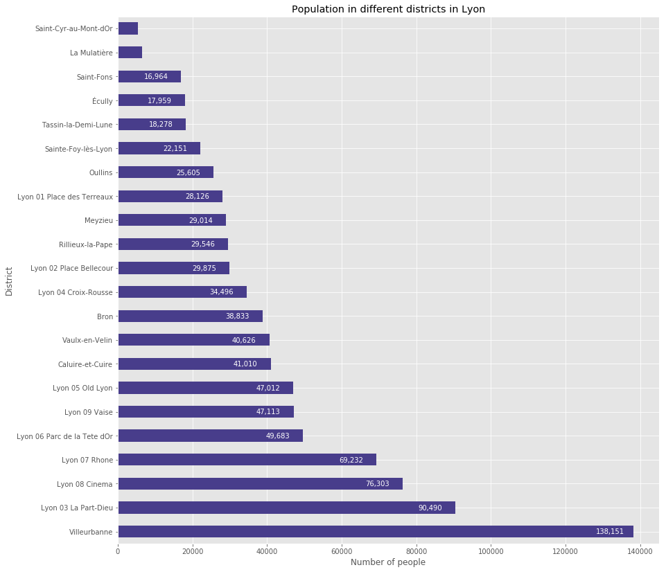

```python
# plot a line graph
loc.sort_values(by='Population', ascending=False, axis=0, inplace=True)
loc['Population'].plot(kind='barh', figsize=(14, 14), color='darkslateblue')
plt.title('Population in different districts in Lyon')
plt.ylabel('District')
plt.xlabel('Number of people')
for index, value in enumerate(loc['Population']):
    label = format(int(value), ',')
    plt.annotate(label, xy=(value - 10000, index - 0.10), color='white')
plt.show()
```

# 3. The replication of the analysis with Lyon data set

Here we inquire the latitude and longitude values of Lyon

```python
address = 'Lyon, France'

geolocator = Nominatim(user_agent="ny_explorer")
location = geolocator.geocode(address)
latitude = location.latitude
longitude = location.longitude
print('The geograpical coordinate of Lyon are {}, {}.'.format(latitude, longitude))
# The latitude and longitude of Lyon are 45.76 degrees North and 4.835 degrees East
```

```
The geograpical coordinate of Lyon are 45.7578137, 4.8320114.
```

## Presenting the map of Lyon

We create a map of Lyon with neighborhoods superimposed on top.

```python
# loc.reset_index() # why reset_index() do not work
# loc[["Latitude", "Longitude", "Population"]]
loc.reset_index(inplace = True)
loc
```

|  | District | Latitude | Longitude | Population |
| --- | --- | --- | --- | --- |
| 0 | Villeurbanne | 45.7667 | 4.8833 | 138151 |
| 1 | Lyon 03 La Part-Dieu | 45.7612 | 4.8518 | 90490 |
| 2 | Lyon 08 Cinema | 45.7363 | 4.8687 | 76303 |
| 3 | Lyon 07 Rhone | 45.7452 | 4.8420 | 69232 |
| 4 | Lyon 06 Parc de la Tete dOr | 45.7679 | 4.8506 | 49683 |
| 5 | Lyon 09 Vaise | 45.7726 | 4.8033 | 47113 |
| 6 | Lyon 05 Old Lyon | 45.7611 | 4.8268 | 47012 |
| 7 | Caluire-et-Cuire | 45.8000 | 4.8500 | 41010 |
| 8 | Vaulx-en-Velin | 45.7833 | 4.9333 | 40626 |
| 9 | Bron | 45.7333 | 4.9167 | 38833 |
| 10 | Lyon 04 Croix-Rousse | 45.7751 | 4.8271 | 34496 |
| 11 | Lyon 02 Place Bellecour | 45.7542 | 4.8309 | 29875 |
| 12 | Rillieux-la-Pape | 45.8240 | 4.8960 | 29546 |
| 13 | Meyzieu | 45.7660 | 5.0000 | 29014 |
| 14 | Lyon 01 Place des Terreaux | 45.7670 | 4.8340 | 28126 |
| 15 | Oullins | 45.7167 | 4.8000 | 25605 |
| 16 | Sainte-Foy-lès-Lyon | 45.7333 | 4.8000 | 22151 |
| 17 | Tassin-la-Demi-Lune | 45.7667 | 4.7833 | 18278 |
| 18 | Écully | 45.7667 | 4.7667 | 17959 |
| 19 | Saint-Fons | 45.7000 | 4.8667 | 16964 |
| 20 | La Mulatière | 45.7333 | 4.8000 | 6540 |
| 21 | Saint-Cyr-au-Mont-dOr | 45.8000 | 4.8167 | 5385 |

```python
# create map of Lyon using latitude and longitude values

# loc.reset_index()
map_lyon = folium.Map(location=[latitude, longitude], zoom_start=13)

# add markers to map
for lat, lng, district, population in zip(loc['Latitude'], loc['Longitude'], loc['District'], loc['Population']):
    label = '{}'.format(district)
    label = folium.Popup(label, parse_html=True)
    folium.CircleMarker(
        [lat, lng],
        radius=5,
        popup=label,
        color='blue',
        fill=True,
        fill_color='#3186cc',
        fill_opacity=0.7,
        parse_html=False).add_to(map_lyon)
map_lyon
```

[interactive chart not shown]

## The Foursquare part - locate venues around neigbourhoods

Here we define Foursquare Credentials and Version

```python
CLIENT_ID = '0FCBIGWFDP2POC2XD0N42WNDORURPZH1WOT035YW3RZPKMMI' # your Foursquare ID
CLIENT_SECRET = 'NM1SU41QBCKUMK0L2U3H2PTHADXSRSWYD04C231ZMHGN4YJB' # your Foursquare Secret
VERSION = '20180605' # Foursquare API version

print('Your credentails:')
print('CLIENT_ID: ' + CLIENT_ID)
print('CLIENT_SECRET:' + CLIENT_SECRET)
```

```
Your credentails:
CLIENT_ID: 0FCBIGWFDP2POC2XD0N42WNDORURPZH1WOT035YW3RZPKMMI
CLIENT_SECRET:NM1SU41QBCKUMK0L2U3H2PTHADXSRSWYD04C231ZMHGN4YJB
```

```python
loc.loc[0, 'District'] # one arbitary neighborhood's name
```

```
'Villeurbanne'
```

We will get the neighborhood's latitude and longitude values.

```python
neighborhood_latitude = loc.loc[0, 'Latitude'] # neighborhood latitude value
neighborhood_longitude = loc.loc[0, 'Longitude'] # neighborhood longitude value
neighborhood_population = loc.loc[0, 'Population'] # neighborhood longitude value
neighborhood_name = loc.loc[0, 'District'] # neighborhood name

print('Latitude and longitude values of {} are {}, {} and population is {}.'.format(neighborhood_name,
                                                               neighborhood_latitude,
                                                               neighborhood_longitude, neighborhood_population))
```

```
Latitude and longitude values of Villeurbanne are 45.7667, 4.8833 and population is 138151.
```

```python
LIMIT = 100 # limit of number of venues returned by Foursquare API
radius = 500 # define radius
# create URL
url = 'https://api.foursquare.com/v2/venues/explore?&client_id={}&client_secret={}&v={}&ll={},{}&radius={}&limit={}'.format(
    CLIENT_ID,
    CLIENT_SECRET,
    VERSION,
    neighborhood_latitude,
    neighborhood_longitude,
    radius,
    LIMIT)
url # display URL
```

```
'https://api.foursquare.com/v2/venues/explore?&client_id=0FCBIGWFDP2POC2XD0N42WNDORURPZH1WOT035YW3RZPKMMI&client_secret=NM1SU41QBCKUMK0L2U3H2PTHADXSRSWYD04C231ZMHGN4YJB&v=20180605&ll=45.7667,4.8833&radius=500&limit=100'
```

Here we send the GET request and examine the resutls

```python
results = requests.get(url).json()
results
```

[output not shown]

[output cut: 289 more lines]

[output not shown]

Now we can borrow the get_category_type function from the Foursquare lab

```python
# function that extracts the category of the venue
def get_category_type(row):
    try:
        categories_list = row['categories']
    except:
        categories_list = row['venue.categories']

    if len(categories_list) == 0:
        return None
    else:
        return categories_list[0]['name']
```

Now we are ready to clean the json and structure it into a pandas dataframe

```python
venues = results['response']['groups'][0]['items']

nearby_venues = json_normalize(venues) # flatten JSON

# filter columns
filtered_columns = ['venue.name', 'venue.categories', 'venue.location.lat', 'venue.location.lng']
nearby_venues =nearby_venues.loc[:, filtered_columns]

# filter the category for each row
nearby_venues['venue.categories'] = nearby_venues.apply(get_category_type, axis=1)

# clean columns
nearby_venues.columns = [col.split(".")[-1] for col in nearby_venues.columns]

nearby_venues.head(10)
```

|  | name | categories | lat | lng |
| --- | --- | --- | --- | --- |
| 0 | Bieristan | Beer Bar | 45.767923 | 4.883442 |
| 1 | TNP | Comedy Club | 45.765965 | 4.879717 |
| 2 | Maison Bettant | Bakery | 45.767525 | 4.879579 |
| 3 | Ninkasi Gratte-Ciel | Bar | 45.769243 | 4.879381 |
| 4 | Starbucks | Coffee Shop | 45.767150 | 4.879479 |
| 5 | Boutique Orange | Electronics Store | 45.767587 | 4.879753 |
| 6 | Monoprix | Supermarket | 45.769594 | 4.880118 |
| 7 | Subway | Sandwich Place | 45.766578 | 4.879452 |
| 8 | Carrefour Market | Supermarket | 45.764780 | 4.880370 |
| 9 | McDonald's | Fast Food Restaurant | 45.767002 | 4.879595 |

And how many venues were returned by Foursquare?

```python
print('{} venues were returned by Foursquare.'.format(nearby_venues.shape[0]))
```

```
11 venues were returned by Foursquare.
```

## Explore neighborhoods in Lyon

Let's create a function to repeat the same process to all the neighborhoods in Lyon.

```python
def getNearbyVenues(names, latitudes, longitudes, radius=500):

    venues_list=[]
    for name, lat, lng in zip(names, latitudes, longitudes):
        print(name)

        # create the API request URL
        url = 'https://api.foursquare.com/v2/venues/explore?&client_id={}&client_secret={}&v={}&ll={},{}&radius={}&limit={}'.format(
            CLIENT_ID,
            CLIENT_SECRET,
            VERSION,
            lat,
            lng,
            radius,
            LIMIT)

        # make the GET request
        results = requests.get(url).json()["response"]['groups'][0]['items']

        # return only relevant information for each nearby venue
        venues_list.append([(
            name,
            lat,
            lng,
            v['venue']['name'],
            v['venue']['location']['lat'],
            v['venue']['location']['lng'],
            v['venue']['categories'][0]['name']) for v in results])

    nearby_venues = pd.DataFrame([item for venue_list in venues_list for item in venue_list])
    nearby_venues.columns = ['Neighborhood',
                  'Neighborhood Latitude',
                  'Neighborhood Longitude',
                  'Venue',
                  'Venue Latitude',
                  'Venue Longitude',
                  'Venue Category']

    return(nearby_venues)
```

Now write the code to run the above function on each neighborhood and create a new dataframe called lyon_venues.

```python
lyon_venues = getNearbyVenues(names=loc['District'],
                                   latitudes=loc['Latitude'],
                                   longitudes=loc['Longitude']
                                  )
```

```
Villeurbanne
Lyon 03 La Part-Dieu
Lyon 08 Cinema
Lyon 07 Rhone
Lyon 06 Parc de la Tete dOr
Lyon 09 Vaise
Lyon 05 Old Lyon
Caluire-et-Cuire
Vaulx-en-Velin
Bron
Lyon 04 Croix-Rousse
Lyon 02 Place Bellecour
Rillieux-la-Pape
Meyzieu
Lyon 01 Place des Terreaux
Oullins
Sainte-Foy-lès-Lyon
Tassin-la-Demi-Lune
Écully
Saint-Fons
La Mulatière
Saint-Cyr-au-Mont-dOr
```

Let's check the size of the resulting dataframe

```python
print(lyon_venues.shape)
lyon_venues.head(10)
```

```
(487, 7)
```

|  | Neighborhood | Neighborhood Latitude | Neighborhood Longitude | Venue | Venue Latitude | Venue Longitude | Venue Category |
| --- | --- | --- | --- | --- | --- | --- | --- |
| 0 | Villeurbanne | 45.7667 | 4.8833 | Bieristan | 45.767923 | 4.883442 | Beer Bar |
| 1 | Villeurbanne | 45.7667 | 4.8833 | TNP | 45.765965 | 4.879717 | Comedy Club |
| 2 | Villeurbanne | 45.7667 | 4.8833 | Maison Bettant | 45.767525 | 4.879579 | Bakery |
| 3 | Villeurbanne | 45.7667 | 4.8833 | Ninkasi Gratte-Ciel | 45.769243 | 4.879381 | Bar |
| 4 | Villeurbanne | 45.7667 | 4.8833 | Starbucks | 45.767150 | 4.879479 | Coffee Shop |
| 5 | Villeurbanne | 45.7667 | 4.8833 | Boutique Orange | 45.767587 | 4.879753 | Electronics Store |
| 6 | Villeurbanne | 45.7667 | 4.8833 | Monoprix | 45.769594 | 4.880118 | Supermarket |
| 7 | Villeurbanne | 45.7667 | 4.8833 | Subway | 45.766578 | 4.879452 | Sandwich Place |
| 8 | Villeurbanne | 45.7667 | 4.8833 | Carrefour Market | 45.764780 | 4.880370 | Supermarket |
| 9 | Villeurbanne | 45.7667 | 4.8833 | McDonald's | 45.767002 | 4.879595 | Fast Food Restaurant |

Let's check how many venues were returned for each neighborhood

```python
lyon_venues.groupby('Neighborhood').count()
```

| Neighborhood | Neighborhood Latitude | Neighborhood Longitude | Venue | Venue Latitude | Venue Longitude | Venue Category |
| --- | --- | --- | --- | --- | --- | --- |
| Bron | 6 | 6 | 6 | 6 | 6 | 6 |
| Caluire-et-Cuire | 4 | 4 | 4 | 4 | 4 | 4 |
| La Mulatière | 6 | 6 | 6 | 6 | 6 | 6 |
| Lyon 01 Place des Terreaux | 100 | 100 | 100 | 100 | 100 | 100 |
| Lyon 02 Place Bellecour | 82 | 82 | 82 | 82 | 82 | 82 |
| Lyon 03 La Part-Dieu | 62 | 62 | 62 | 62 | 62 | 62 |
| Lyon 04 Croix-Rousse | 35 | 35 | 35 | 35 | 35 | 35 |
| Lyon 05 Old Lyon | 85 | 85 | 85 | 85 | 85 | 85 |
| Lyon 06 Parc de la Tete dOr | 29 | 29 | 29 | 29 | 29 | 29 |
| Lyon 07 Rhone | 18 | 18 | 18 | 18 | 18 | 18 |
| Lyon 08 Cinema | 8 | 8 | 8 | 8 | 8 | 8 |
| Lyon 09 Vaise | 7 | 7 | 7 | 7 | 7 | 7 |
| Meyzieu | 5 | 5 | 5 | 5 | 5 | 5 |
| Oullins | 4 | 4 | 4 | 4 | 4 | 4 |
| Rillieux-la-Pape | 2 | 2 | 2 | 2 | 2 | 2 |
| Saint-Cyr-au-Mont-dOr | 2 | 2 | 2 | 2 | 2 | 2 |
| Saint-Fons | 1 | 1 | 1 | 1 | 1 | 1 |
| Sainte-Foy-lès-Lyon | 6 | 6 | 6 | 6 | 6 | 6 |
| Tassin-la-Demi-Lune | 6 | 6 | 6 | 6 | 6 | 6 |
| Vaulx-en-Velin | 1 | 1 | 1 | 1 | 1 | 1 |
| Villeurbanne | 11 | 11 | 11 | 11 | 11 | 11 |
| Écully | 7 | 7 | 7 | 7 | 7 | 7 |

Let's find out how many unique categories can be curated from all the returned venues

```python
print('There are {} uniques categories.'.format(len(lyon_venues['Venue Category'].unique())))
```

```
There are 118 uniques categories.
```

## Analyzing each neighborhood by neighborhood

```python
# one hot encoding
lyon_onehot = pd.get_dummies(lyon_venues[['Venue Category']], prefix="", prefix_sep="")

# add neighborhood column back to dataframe
lyon_onehot['Neighborhood'] = lyon_venues['Neighborhood']

# move neighborhood column to the first column
fixed_columns = [lyon_onehot.columns[-1]] + list(lyon_onehot.columns[:-1])
lyon_onehot = lyon_onehot[fixed_columns]

lyon_onehot.head(6)
```

|  | Wine Bar | Art Museum | Asian Restaurant | Bagel Shop | Bakery | Bank | Bar | Beer Bar | Beer Garden | Belgian Restaurant | Bistro | Bookstore | Brazilian Restaurant | Breakfast Spot | Bridge | Burger Joint | Bus Stop | Café | Cheese Shop | Chocolate Shop | Church | City Hall | Clothing Store | Cocktail Bar | Coffee Shop | Comedy Club | Concert Hall | Cosmetics Shop | Creperie | … |
| --- | --- | --- | --- | --- | --- | --- | --- | --- | --- | --- | --- | --- | --- | --- | --- | --- | --- | --- | --- | --- | --- | --- | --- | --- | --- | --- | --- | --- | --- | --- |
| 0 | 0 | 0 | 0 | 0 | 0 | 0 | 0 | 1 | 0 | 0 | 0 | 0 | 0 | 0 | 0 | 0 | 0 | 0 | 0 | 0 | 0 | 0 | 0 | 0 | 0 | 0 | 0 | 0 | 0 | … |
| 1 | 0 | 0 | 0 | 0 | 0 | 0 | 0 | 0 | 0 | 0 | 0 | 0 | 0 | 0 | 0 | 0 | 0 | 0 | 0 | 0 | 0 | 0 | 0 | 0 | 0 | 1 | 0 | 0 | 0 | … |
| 2 | 0 | 0 | 0 | 0 | 1 | 0 | 0 | 0 | 0 | 0 | 0 | 0 | 0 | 0 | 0 | 0 | 0 | 0 | 0 | 0 | 0 | 0 | 0 | 0 | 0 | 0 | 0 | 0 | 0 | … |
| 3 | 0 | 0 | 0 | 0 | 0 | 0 | 1 | 0 | 0 | 0 | 0 | 0 | 0 | 0 | 0 | 0 | 0 | 0 | 0 | 0 | 0 | 0 | 0 | 0 | 0 | 0 | 0 | 0 | 0 | … |
| 4 | 0 | 0 | 0 | 0 | 0 | 0 | 0 | 0 | 0 | 0 | 0 | 0 | 0 | 0 | 0 | 0 | 0 | 0 | 0 | 0 | 0 | 0 | 0 | 0 | 1 | 0 | 0 | 0 | 0 | … |
| 5 | 0 | 0 | 0 | 0 | 0 | 0 | 0 | 0 | 0 | 0 | 0 | 0 | 0 | 0 | 0 | 0 | 0 | 0 | 0 | 0 | 0 | 0 | 0 | 0 | 0 | 0 | 0 | 0 | 0 | … |

```python
lyon_onehot.shape
```

```
(487, 118)
```

Next, let's group rows by neighborhood and by taking the mean of the frequency of occurrence of each category.

```python
lyon_grouped = lyon_onehot.groupby('Neighborhood').mean().reset_index() # (inplace=True)
# lyon_grouped = lyon_onehot.groupby('Neighborhood').mean()
# lyon_grouped.index
# https://stackoverflow.com/questions/52330016/pandas-reset-index-after-performing-groupby-and-retain-selective-columns
# https://github.com/dask/dask/issues/2929
# https://stackoverflow.com/questions/22407798/how-to-reset-a-dataframes-indexes-for-all-groups-in-one-step
# https://intellipaat.com/community/3011/pandas-resetindex-after-groupby-valuecounts
```

Let's confirm the new size.

```python
lyon_grouped.shape
```

```
(22, 118)
```

Let's print each neighborhood along with the top 5 most common venues.

```python
num_top_venues = 5

for hood in lyon_grouped['Neighborhood']:
    print("----"+hood+"----")
    temp = lyon_grouped[lyon_grouped['Neighborhood'] == hood].T.reset_index()
    temp.columns = ['venue','freq']
    temp = temp.iloc[1:]
    temp['freq'] = temp['freq'].astype(float)
    temp = temp.round({'freq': 2})
    print(temp.sort_values('freq', ascending=False).reset_index(drop=True).head(num_top_venues))
    print('\n')
```

```
----Bron----
                venue  freq
0  Salon / Barbershop  0.17
1         Coffee Shop  0.17
2               Hotel  0.17
3              Bakery  0.17
4        Tram Station  0.17


----Caluire-et-Cuire----
               venue  freq
0        Gas Station  0.25
1              Diner  0.25
2              Plaza  0.25
3  Food & Drink Shop  0.25
4  Indian Restaurant  0.00


----La Mulatière----
                 venue  freq
0             Bus Stop  0.17
1          Coffee Shop  0.17
2  Indie Movie Theater  0.17
3                 Bank  0.17
4    French Restaurant  0.17


----Lyon 01 Place des Terreaux----
               venue  freq
0  French Restaurant  0.12
1                Bar  0.10
2        Coffee Shop  0.06
3              Plaza  0.05
4               Café  0.05


----Lyon 02 Place Bellecour----
               venue  freq
0  French Restaurant  0.26
1               Café  0.10
```

[output cut: 141 more lines]

```
               venue  freq
0        Supermarket  0.27
1                Bar  0.09
2  Electronics Store  0.09
3        Coffee Shop  0.09
4        Comedy Club  0.09


----Écully----
                  venue  freq
0              Bus Stop  0.14
1                Bakery  0.14
2  Fast Food Restaurant  0.14
3        Clothing Store  0.14
4   Sporting Goods Shop  0.14
```

Let's put that into a pandas dataframe.

First, let's write a function to sort the venues in descending order.

```python
def return_most_common_venues(row, num_top_venues):
    row_categories = row.iloc[1:]
    row_categories_sorted = row_categories.sort_values(ascending=False)

    return row_categories_sorted.index.values[0:num_top_venues]
```

Now let's create the new dataframe and display the top 10 venues for each neighborhood.

```python
num_top_venues = 10

indicators = ['st', 'nd', 'rd']

# create columns according to number of top venues
columns = ['Neighborhood']
for ind in np.arange(num_top_venues):
    try:
        columns.append('{}{} Most Common Venue'.format(ind+1, indicators[ind]))
    except:
        columns.append('{}th Most Common Venue'.format(ind+1))

# create a new dataframe
neighborhoods_venues_sorted = pd.DataFrame(columns=columns)
neighborhoods_venues_sorted['Neighborhood'] = lyon_grouped['Neighborhood']

for ind in np.arange(lyon_grouped.shape[0]):
    neighborhoods_venues_sorted.iloc[ind, 1:] = return_most_common_venues(lyon_grouped.iloc[ind, :], num_top_venues)

neighborhoods_venues_sorted.head()
```

|  | Neighborhood | 1st Most Common Venue | 2nd Most Common Venue | 3rd Most Common Venue | 4th Most Common Venue | 5th Most Common Venue | 6th Most Common Venue | 7th Most Common Venue | 8th Most Common Venue | 9th Most Common Venue | 10th Most Common Venue |
| --- | --- | --- | --- | --- | --- | --- | --- | --- | --- | --- | --- |
| 0 | Bron | Hotel | Bakery | Salon / Barbershop | Coffee Shop | Middle Eastern Restaurant | Tram Station | Gym / Fitness Center | Food & Drink Shop | Department Store | Dessert Shop |
| 1 | Caluire-et-Cuire | Plaza | Diner | Gas Station | Food & Drink Shop | Vietnamese Restaurant | Furniture / Home Store | Department Store | Dessert Shop | Donut Shop | Electronics Store |
| 2 | La Mulatière | Coffee Shop | Bank | French Restaurant | Toy / Game Store | Bus Stop | Indie Movie Theater | Donut Shop | Diner | Furniture / Home Store | Electronics Store |
| 3 | Lyon 01 Place des Terreaux | French Restaurant | Bar | Coffee Shop | Plaza | Café | Cocktail Bar | Lounge | Pub | Japanese Restaurant | Lyonese Bouchon |
| 4 | Lyon 02 Place Bellecour | French Restaurant | Café | Hotel | Plaza | Sandwich Place | Bakery | Italian Restaurant | Bistro | Asian Restaurant | Restaurant |

## Clustering the neighborhoods

```python
# set number of clusters
kclusters = 5

lyon_grouped_clustering = lyon_grouped.drop('Neighborhood', 1)

# run k-means clustering
# kmeans = KMeans(n_clusters=kclusters, random_state=0).fit(lyon_grouped_clustering)
kmeans = KMeans(init="k-means++", n_clusters=kclusters, random_state=0, n_init=12).fit(lyon_grouped_clustering)

# check cluster labels generated for each row in the dataframe
kmeans.labels_[0:10]
```

```
array([1, 1, 1, 1, 1, 1, 1, 1, 1, 1], dtype=int32)
```

```python
# add clustering labels
neighborhoods_venues_sorted.insert(0, 'Cluster Labels', kmeans.labels_)

lyon_merged = loc

# merge lyon_grouped with lyon_data to add latitude/longitude for each neighborhood
# lyon_merged = lyon_merged.join(neighborhoods_venues_sorted.set_index('Neighborhood'), on='Neighbourhood')

lyon_merged.head() # check the last columns!
```

|  | District | Latitude | Longitude | Population |
| --- | --- | --- | --- | --- |
| 0 | Villeurbanne | 45.7667 | 4.8833 | 138151 |
| 1 | Lyon 03 La Part-Dieu | 45.7612 | 4.8518 | 90490 |
| 2 | Lyon 08 Cinema | 45.7363 | 4.8687 | 76303 |
| 3 | Lyon 07 Rhone | 45.7452 | 4.8420 | 69232 |
| 4 | Lyon 06 Parc de la Tete dOr | 45.7679 | 4.8506 | 49683 |

Finally, let's visualize the resulting clusters.

```python
# create map
map_clusters = folium.Map(location=[latitude, longitude], zoom_start=11)

# set color scheme for the clusters
x = np.arange(kclusters)
ys = [i + x + (i*x)**2 for i in range(kclusters)]
colors_array = cm.rainbow(np.linspace(0, 1, len(ys)))
rainbow = [colors.rgb2hex(i) for i in colors_array]

# add markers to the map
markers_colors = []
for lat, lon, poi, cluster in zip(lyon_merged['Latitude'], lyon_merged['Longitude'], lyon_merged['Neighborhood'], lyon_merged['Cluster Labels']):
    label = folium.Popup(str(poi) + ' Cluster ' + str(cluster), parse_html=True)
    folium.CircleMarker(
        [lat, lon],
        radius=5,
        popup=label,
        color=rainbow[cluster-1],
        fill=True,
        fill_color=rainbow[cluster-1],
        fill_opacity=0.7).add_to(map_clusters)

map_clusters
```

[output not shown]

## Examining clusters and giving them names

Now, you can examine each cluster and determine the discriminating venue categories that distinguish each cluster. Based on the defining categories, you can then assign a name to each cluster.

**Cluster 1 - Red - Coffee Shops and Delicates**

```python
lyon_merged.loc[lyon_merged['Cluster Labels'] == 0, lyon_merged.columns[[1] + list(range(5, lyon_merged.shape[1]))]]
```

[output not shown]

**Cluster 2 - Purple - Bermunada Triangle**

```python
lyon_merged.loc[lyon_merged['Cluster Labels'] == 1, lyon_merged.columns[[1] + list(range(5, lyon_merged.shape[1]))]]
```

[output not shown]

**Cluster 3 - Petrol Blue - Locks and Latches**

```python
lyon_merged.loc[lyon_merged['Cluster Labels'] == 2, lyon_merged.columns[[1] + list(range(5, lyon_merged.shape[1]))]]
```

[output not shown]

**Cluster 4 - Darker Green - Boutiques**

```python
lyon_merged.loc[lyon_merged['Cluster Labels'] == 3, lyon_merged.columns[[1] + list(range(5, lyon_merged.shape[1]))]]
```

[output not shown]

**Cluster 5 - Light Green - Parks**

```python
lyon_merged.loc[lyon_merged['Cluster Labels'] == 4, lyon_merged.columns[[1] + list(range(5, lyon_merged.shape[1]))]]
```

[output not shown]

```python
# lyon_merged.loc[lyon_merged['Cluster Labels'] == 5, lyon_merged.columns[[1] + list(range(5, lyon_merged.shape[1]))]]
```

```python
print('The full analysis is ready')
```